# Factor Analysis Materials

Author

Brier Gallihugh, M.S.

Published

July 11, 2024

## Creating Data

```r
library(tidyverse)
library(pastecs)
library(GPArotation)
library(psych)
set.seed(10311993)

data <- psych::bfi

proposed_scale <- psych::bfi[,1:15]

proposed_scale <- proposed_scale %>% na.omit()

proposed_scale <- proposed_scale[sample(nrow(proposed_scale), size=500),]

cor_proposed_scale <- cor(proposed_scale, use = "pairwise.complete.obs")

apaTables::apa.cor.table(cor_proposed_scale,filename = "CorTable.doc")

# For Readability
round(cor(proposed_scale, use = "pairwise.complete.obs"),2)
```

**1**

Create a data set using the `bfi` dataset in the `psych` package

**2**

Create a correlation matrix of the `bfi` items using the `cor()` function

**3**

Create an APA Style correlation output within Word

**4**

Round correlation matrix to 2 decimal places for readability in R

```
Means, standard deviations, and correlations with confidence intervals


  Variable M     SD   1            2            3            4
  1. A1    0.01  0.32

  2. A2    0.17  0.36 -.77**
                      [-.92, -.43]

  3. A3    0.18  0.37 -.73**       .85**
                      [-.91, -.35] [.59, .95]

  4. A4    0.15  0.32 -.60*        .72**        .69**
                      [-.85, -.13] [.32, .90]   [.28, .89]

  5. A5    0.18  0.37 -.65**       .77**        .90**        .70**
                      [-.87, -.21] [.43, .92]   [.73, .97]   [.30, .89]

  6. C1    0.12  0.33 -.20         .36          .23          .31
                      [-.65, .35]  [-.19, .73]  [-.32, .66]  [-.24, .71]

  7. C2    0.15  0.33 -.24         .38          .21          .38
                      [-.67, .31]  [-.17, .75]  [-.34, .65]  [-.16, .75]

  8. C3    0.12  0.32 -.28         .34          .18          .22
                      [-.69, .28]  [-.21, .73]  [-.37, .63]  [-.33, .66]

  9. C4    -0.01 0.38 .33          -.57*        -.43         -.54*
                      [-.22, .72]  [-.84, -.08] [-.77, .11]  [-.82, -.03]

  10. C5   -0.01 0.36 .33          -.57*        -.49         -.61*
                      [-.22, .72]  [-.84, -.08] [-.80, .03]  [-.86, -.14]

  11. E1   -0.02 0.38 .42          -.71**       -.75**       -.61*
                      [-.11, .77]  [-.89, -.30] [-.91, -.40] [-.85, -.13]

  12. E2   -0.03 0.41 .43          -.72**       -.77**       -.65**
                      [-.10, .77]  [-.90, -.33] [-.92, -.42] [-.87, -.20]

  13. E3   0.17  0.37 -.47         .69**        .80**        .62*
```

[output cut: 123 more lines]

```
A1 -0.08 -0.09  0.00
A2  0.32  0.27  0.34
A3  0.44  0.37  0.25
A4  0.26  0.30  0.23
A5  0.47  0.50  0.24
C1  0.14  0.13  0.21
C2  0.12  0.06  0.31
C3  0.02  0.04  0.25
C4 -0.06 -0.10 -0.28
C5 -0.17 -0.16 -0.24
E1 -0.38 -0.44 -0.30
E2 -0.43 -0.55 -0.36
E3  1.00  0.47  0.36
E4  0.47  1.00  0.26
E5  0.36  0.26  1.00
```

## EFA Assumptions

```r
#Barlett Test for New Scale
cortest.bartlett(cor_proposed_scale, n = 500)

#KMO for New Scale
KMO(cor_proposed_scale)

#Determinent for New Scale
det(cor_proposed_scale)
```

**1**

Run a Bartlett test on the correlation matrix. Ideally, this should have a p value of less than .05

**2**

Run a KMO on the proposed correlation matrix. Ideally this is greater than KMO = .90

**3**

```
$chisq
[1] 2225.86

$p.value
[1] 0

$df
[1] 105

Kaiser-Meyer-Olkin factor adequacy
Call: KMO(r = cor_proposed_scale)
Overall MSA =  0.82
MSA for each item =
  A1   A2   A3   A4   A5   C1   C2   C3   C4   C5   E1   E2   E3   E4   E5
0.73 0.86 0.85 0.86 0.83 0.83 0.77 0.79 0.76 0.78 0.85 0.80 0.88 0.84 0.85
[1] 0.0109611
```

## EFA Factor Structure

```r
psych::scree(cor_proposed_scale)
```

**3**

Run an orthogonal rotation factor analysis using the `fa()` function

**4**

Print the output fit measures using the `print.psych()` function. The `SORT = TRUE` argument sorts the factor loading by loading magnitude.

**5**

Run an oblique rotation factor analysis using the `fa()` function

**6**

Print the output again using the `print.psych()` function

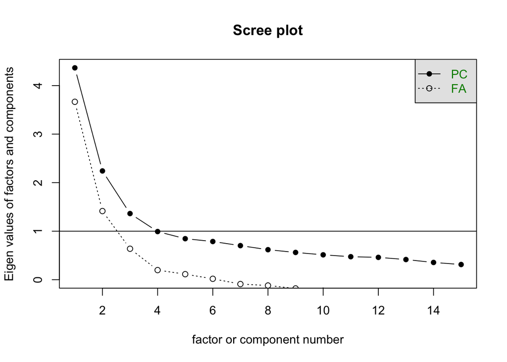

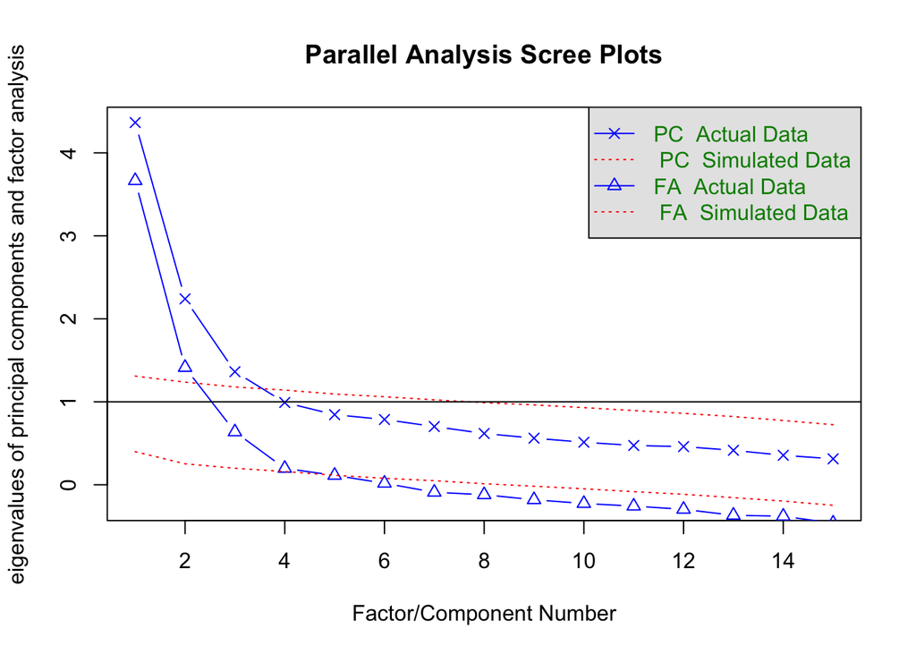

```r
fa.parallel(cor_proposed_scale, n.obs = 500)
```

```r
# Suggests 4 Factor Solution

# Orthogonal (Non Correlated)
orthoFA3 <- fa(r = cor_proposed_scale, nfactors = 4,rotate = 'varimax', use = "pairwise.complete.obs")
#Show All Info
print.psych(orthoFA3, sort = TRUE)

# Oblique (Correlated)
obliqueFA3 <- fa(r = cor_proposed_scale, nfactors = 4,rotate = 'oblimin', use = "pairwise.complete.obs")
print.psych(obliqueFA3, sort = TRUE)
```

```
Parallel analysis suggests that the number of factors =  4  and the number of components =  3
Factor Analysis using method =  minres
Call: fa(r = cor_proposed_scale, nfactors = 4, rotate = "varimax",
    use = "pairwise.complete.obs")
Standardized loadings (pattern matrix) based upon correlation matrix
   item   MR1   MR2   MR3   MR4   h2   u2 com
A3    3  0.73  0.05  0.17 -0.19 0.60 0.40 1.3
A5    5  0.67  0.05  0.27 -0.07 0.53 0.47 1.4
A2    2  0.57  0.21  0.13 -0.28 0.47 0.53 1.9
E3   13  0.53  0.07  0.45  0.16 0.51 0.49 2.2
A4    4  0.43  0.19  0.13 -0.11 0.25 0.75 1.7
C2    7  0.17  0.70 -0.10  0.12 0.54 0.46 1.2
C4    9  0.03 -0.69 -0.18  0.23 0.57 0.43 1.4
C1    6  0.07  0.56  0.08  0.08 0.34 0.66 1.1
C5   10 -0.05 -0.56 -0.20  0.15 0.38 0.62 1.4
C3    8  0.11  0.55 -0.10 -0.03 0.33 0.67 1.2
E5   15  0.28  0.38  0.32  0.10 0.33 0.67 3.0
E2   12 -0.16 -0.10 -0.83  0.11 0.73 0.27 1.1
E1   11 -0.22 -0.01 -0.60  0.07 0.42 0.58 1.3
E4   14  0.42  0.05  0.57  0.08 0.51 0.49 1.9
A1    1 -0.30 -0.02 -0.02  0.56 0.40 0.60 1.5

                       MR1  MR2  MR3  MR4
SS loadings           2.24 2.15 1.91 0.60
Proportion Var        0.15 0.14 0.13 0.04
Cumulative Var        0.15 0.29 0.42 0.46
Proportion Explained  0.32 0.31 0.28 0.09
Cumulative Proportion 0.32 0.64 0.91 1.00

Mean item complexity =  1.6
Test of the hypothesis that 4 factors are sufficient.

df null model =  105  with the objective function =  4.51
df of  the model are 51  and the objective function was  0.3

The root mean square of the residuals (RMSR) is  0.03
The df corrected root mean square of the residuals is  0.04

Fit based upon off diagonal values = 0.99
Measures of factor score adequacy
```

[output cut: 39 more lines]

```
Mean item complexity =  1.5
Test of the hypothesis that 4 factors are sufficient.

df null model =  105  with the objective function =  4.51
df of  the model are 51  and the objective function was  0.3

The root mean square of the residuals (RMSR) is  0.03
The df corrected root mean square of the residuals is  0.04

Fit based upon off diagonal values = 0.99
Measures of factor score adequacy
                                                   MR1  MR2  MR3   MR4
Correlation of (regression) scores with factors   0.91 0.89 0.91  0.70
Multiple R square of scores with factors          0.82 0.80 0.83  0.49
Minimum correlation of possible factor scores     0.64 0.60 0.65 -0.02
```

**Tip**

More often than not, an oblique rotation will be the best fit for your data as it assumes that your items are correlated with one another

## EFA Factor Structure Assumptions

```r
#Standard Residuals
obliqueFA3Residuals <- scale(obliqueFA3$residual)
#Test Normality
shapiro.test(obliqueFA3Residuals)
#Histogram
hist(obliqueFA3Residuals, col = 'lightgrey',
     main="", xlab = "EFA Model Residuals, FA = 3 (Oblique)",
     probability = TRUE)
curve(dnorm(x, mean = mean(obliqueFA3Residuals),
            sd = sd(obliqueFA3Residuals)),
            add = TRUE, lwd = 2, col = 'blue')
```

**1**

Assess the residuals of your desired factor loading solution using the `scale()` function in combination with extracting the residuals using `object$residuals` notation.

**2**

Statistical test of the factor solution residuals using the `shapiro.test()` function.

**3**

Graphical depiction of the solution residuals with a normal curve overlay in the color blue

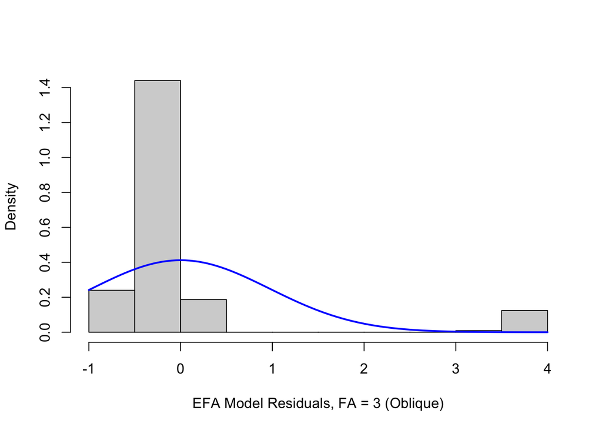

```
    Shapiro-Wilk normality test

data:  obliqueFA3Residuals
W = 0.46308, p-value < 2.2e-16
```

## Calculating Reliability

```r
#Items
Factor1<- c("A1","A2","A3","A4","A5")
Factor2<- c("C1","C2","C3","C4","C5")
Factor3<- c("E1","E2","E3","E4","E5")
Overall <- c("A1","A2","A3","A4","A5","C1","C2","C3","C4","C5","E1","E2","E3","E4","E5")

#Reliability Factor 1
psych::alpha(proposed_scale[,Factor1], check.keys = TRUE)
#Reliability Factor 2
psych::alpha(proposed_scale[, Factor2], check.keys = TRUE)
#Reliablity Factor 3
psych::alpha(proposed_scale[, Factor3], check.keys = TRUE)
#Overall Reliability
psych::alpha(proposed_scale[, Overall], check.keys = TRUE)
```

**1**

Create a subset of items to represent Factor 1

**2**

Create a subset of items to represent Factor 2

**3**

Create a subset of items to represent Factor 3

**4**

Create a subset of items to represent Overall

**5**

Determine the reliability of Factor 1 using the `alpha()` function in the `psych` package. `check.keys` ensures that items that load negatively are reverse coded.

**6**

Determine the reliability of Factor 2 using the `alpha()` function in the `psych` package. `check.keys` ensures that items that load negatively are reverse coded.

**7**

Determine the reliability of Factor 3 using the `alpha()` function in the `psych` package. `check.keys` ensures that items that load negatively are reverse coded.

**8**

Determine the reliability of Overall using the `alpha()` function in the `psych` package. `check.keys` ensures that items that load negatively are reverse coded.

```
Reliability analysis
Call: psych::alpha(x = proposed_scale[, Factor1], check.keys = TRUE)

  raw_alpha std.alpha G6(smc) average_r  S/N   ase mean   sd median_r
      0.73      0.46    0.56      0.14 0.84 0.019  4.7 0.92     0.34

    95% confidence boundaries
         lower alpha upper
Feldt     0.69  0.73  0.77
Duhachek  0.69  0.73  0.77

 Reliability if an item is dropped:
    raw_alpha std.alpha G6(smc) average_r  S/N alpha se var.r med.r
A1-      0.74      0.75    0.70     0.423 2.93    0.019 0.011 0.377
A2       0.66      0.28    0.42     0.090 0.40    0.025 0.144 0.070
A3       0.64      0.19    0.31     0.054 0.23    0.027 0.122 0.080
A4       0.72      0.31    0.47     0.099 0.44    0.021 0.197 0.087
A5       0.66      0.19    0.34     0.054 0.23    0.025 0.148 0.070

 Item statistics
      n raw.r  std.r r.cor r.drop mean  sd
A1- 500  0.61 -0.033 -0.45   0.36  4.6 1.4
A2  500  0.73  0.677  0.59   0.57  4.8 1.1
A3  500  0.77  0.754  0.75   0.61  4.6 1.3
A4  500  0.66  0.657  0.49   0.41  4.7 1.5
A5  500  0.73  0.753  0.71   0.55  4.5 1.3

Non missing response frequency for each item
      1    2    3    4    5    6 miss
A1 0.33 0.28 0.14 0.13 0.10 0.02    0
A2 0.01 0.05 0.05 0.19 0.40 0.30    0
A3 0.03 0.06 0.08 0.19 0.36 0.27    0
A4 0.05 0.07 0.07 0.16 0.25 0.41    0
A5 0.03 0.06 0.09 0.23 0.33 0.26    0

Reliability analysis
Call: psych::alpha(x = proposed_scale[, Factor2], check.keys = TRUE)

  raw_alpha std.alpha G6(smc) average_r   S/N   ase mean   sd median_r
      0.75     -0.23    0.16    -0.039 -0.19 0.018  4.2 0.94    -0.31
```

[output cut: 114 more lines]

```
A1 0.33 0.28 0.14 0.13 0.10 0.02    0
A2 0.01 0.05 0.05 0.19 0.40 0.30    0
A3 0.03 0.06 0.08 0.19 0.36 0.27    0
A4 0.05 0.07 0.07 0.16 0.25 0.41    0
A5 0.03 0.06 0.09 0.23 0.33 0.26    0
C1 0.02 0.04 0.11 0.22 0.39 0.21    0
C2 0.03 0.09 0.10 0.25 0.34 0.18    0
C3 0.03 0.08 0.11 0.27 0.35 0.16    0
C4 0.24 0.32 0.18 0.18 0.07 0.02    0
C5 0.15 0.19 0.13 0.24 0.14 0.13    0
E1 0.23 0.23 0.15 0.18 0.11 0.10    0
E2 0.19 0.23 0.12 0.22 0.14 0.09    0
E3 0.06 0.10 0.13 0.28 0.28 0.15    0
E4 0.06 0.10 0.09 0.15 0.34 0.26    0
E5 0.04 0.06 0.10 0.24 0.32 0.24    0
```

**Tip**

If you have more than one factor, your scale is no longer one (or uni) dimensional. As such, the idea of an “overall” reliability is questionable at best. Further, all reliability estimates are sample dependent. For non-sample dependent metrics, one should consider Item Response Theory (IRT)